# Exploratory Data Analysis

At the beginning, we conducted exploratory data analysis (EDA) to better understand the data. This step is crucial for subsequent modeling.

```python
import pandas as pd
import sys
import os
sys.path.append(os.getcwd()[:-18])
from source.eda_utils import get_dataFrame_withShortCols, data_cleaner, preprocess_data
import seaborn as snus
import matplotlib.pyplot as plt
```

```python
# read data with defined by us function that renames columns
train_data = get_dataFrame_withShortCols('development_sample.csv')
val_data = get_dataFrame_withShortCols('testing_sample.csv')
```

## Initial Data Overview

```python
# first 5 rows of train (development) data
train_data.head()
```

|  | ID | Customer ID | Application date | Default indicator | Application_status | Number of applicants | Loan purpose | Distribution channel | Application amount | Credit duration | ... | Number of requests during the last 9 months | Number of requests during the last 12 months | Limit on credit card | Amount on current account | Amount on savings account | Arrear in last 3 months | Arrear in last 12 months | Credit bureau score | Average income | _r_ |
| --- | --- | --- | --- | --- | --- | --- | --- | --- | --- | --- | --- | --- | --- | --- | --- | --- | --- | --- | --- | --- | --- |
| 0 | 11034977 | 32537148 | 01Feb2010 0:00:00 | 0.0 | Approved | 1 | 2.0 | 1 | 7800 | 99 | ... | 1 | 1 | 0 | 6768.42 | 0.00 | 0 | 0 | 0 | 3899 | 0.267045 |
| 1 | 11034978 | 32761663 | 01Feb2010 0:00:00 | 0.0 | Approved | 1 | 1.0 | 2 | 11100 | 78 | ... | 0 | 0 | 15000 | 5937.66 | 3870.60 | 0 | 0 | 0 | 3899 | 0.533040 |
| 2 | 11034979 | 32701063 | 01Feb2010 0:00:00 | 0.0 | Approved | 2 | 3.0 | 1 | 2400 | 15 | ... | 2 | 2 | 0 | 5647.77 | 1463.08 | 0 | 0 | 10 | 3899 | 0.861555 |
| 3 | 11034980 | 32386786 | 01Feb2010 0:00:00 | 0.0 | Approved | 3 | 1.0 | 2 | 11800 | 30 | ... | 0 | 0 | 0 | 3594.90 | 21563.78 | 0 | 0 | 10 | 3899 | 0.506451 |
| 4 | 11034981 | 32692110 | 02Feb2010 0:00:00 | NaN | Rejected | 1 | 2.0 | 1 | 10200 | 72 | ... | 2 | 2 | 0 | 9908.45 | 0.00 | 0 | 0 | 20 | 3899 | 0.210913 |

5 rows × 36 columns

```python
# basic stats for variables in dataframe
train_data.describe()
```

|  | ID | Customer ID | Default indicator | Number of applicants | Loan purpose | Application amount | Credit duration | Payment frequency | Installment amount | Value of the goods | ... | Number of requests during the last 9 months | Number of requests during the last 12 months | Limit on credit card | Amount on current account | Amount on savings account | Arrear in last 3 months | Arrear in last 12 months | Credit bureau score | Average income | _r_ |
| --- | --- | --- | --- | --- | --- | --- | --- | --- | --- | --- | --- | --- | --- | --- | --- | --- | --- | --- | --- | --- | --- |
| count | 5.000000e+04 | 5.000000e+04 | 36718.000000 | 50000.00000 | 48597.000000 | 50000.000000 | 50000.000000 | 50000.00000 | 50000.000000 | 20827.000000 | ... | 50000.000000 | 50000.000000 | 50000.000000 | 39912.000000 | 30117.000000 | 50000.000000 | 50000.000000 | 50000.00000 | 50000.000000 | 5.000000e+04 |
| mean | 1.105998e+07 | 3.262894e+07 | 0.030693 | 1.33786 | 1.915098 | 17123.466000 | 42.141900 | 1.54724 | 1330.747722 | 35911.341048 | ... | 1.355780 | 1.714940 | 7693.896000 | 13058.171210 | 24822.929304 | 0.012080 | 0.044480 | 6.78040 | 8182.152860 | 4.980869e-01 |
| std | 1.443390e+04 | 1.537429e+05 | 0.172488 | 0.66462 | 0.861268 | 12217.178461 | 45.378778 | 1.23719 | 1619.370201 | 18153.197904 | ... | 1.591129 | 1.814075 | 20984.098355 | 13389.951429 | 26670.053145 | 0.109244 | 0.206161 | 10.83386 | 3190.983287 | 2.880834e-01 |
| min | 1.103498e+07 | 3.236142e+07 | 0.000000 | 1.00000 | 1.000000 | 700.000000 | 6.000000 | 1.00000 | 53.980000 | 4900.000000 | ... | 0.000000 | 0.000000 | 0.000000 | 260.360000 | 0.000000 | 0.000000 | 0.000000 | 0.00000 | 3899.000000 | 3.953460e-07 |
| 25% | 1.104748e+07 | 3.249680e+07 | 0.000000 | 1.00000 | 1.000000 | 6900.000000 | 15.000000 | 1.00000 | 470.112500 | 21400.000000 | ... | 0.000000 | 0.000000 | 0.000000 | 4989.687500 | 5928.370000 | 0.000000 | 0.000000 | 0.00000 | 5035.000000 | 2.481838e-01 |
| 50% | 1.105998e+07 | 3.263026e+07 | 0.000000 | 1.00000 | 2.000000 | 14100.000000 | 27.000000 | 1.00000 | 842.060000 | 31400.000000 | ... | 1.000000 | 1.000000 | 0.000000 | 9020.885000 | 17291.290000 | 0.000000 | 0.000000 | 0.00000 | 8569.000000 | 4.966425e-01 |
| 75% | 1.107248e+07 | 3.276254e+07 | 0.000000 | 1.00000 | 3.000000 | 24800.000000 | 48.000000 | 1.00000 | 1548.790000 | 47100.000000 | ... | 2.000000 | 2.000000 | 0.000000 | 16279.495000 | 35005.380000 | 0.000000 | 0.000000 | 10.00000 | 11839.000000 | 7.468285e-01 |
| max | 1.108498e+07 | 3.289438e+07 | 1.000000 | 4.00000 | 3.000000 | 63700.000000 | 312.000000 | 6.00000 | 27075.540000 | 138300.000000 | ... | 23.000000 | 26.000000 | 190800.000000 | 260497.970000 | 371035.800000 | 1.000000 | 1.000000 | 250.00000 | 12832.000000 | 9.999984e-01 |

8 rows × 32 columns

```python
# first 5 rows of testing data
val_data.head()
```

|  | ID | Customer ID | Application date | Default indicator | Application_status | Number of applicants | Loan purpose | Distribution channel | Application amount | Credit duration | ... | Number of requests during the last 9 months | Number of requests during the last 12 months | Limit on credit card | Amount on current account | Amount on savings account | Arrear in last 3 months | Arrear in last 12 months | Credit bureau score | Average income | _r_ |
| --- | --- | --- | --- | --- | --- | --- | --- | --- | --- | --- | --- | --- | --- | --- | --- | --- | --- | --- | --- | --- | --- |
| 0 | 36034977 | 32653719 | 03Feb2010 0:00:00 | 0.0 | Approved | 1 | 3.0 | 1.0 | 4800 | 15 | ... | 8 | 8 | 0 | 4977.87 | 14880.28 | 0 | 0 | 70 | 3899 | 0.485674 |
| 1 | 36034978 | 32832365 | 04Feb2010 0:00:00 | 0.0 | Approved | 2 | 2.0 | 1.0 | 6800 | 18 | ... | 1 | 1 | 29400 | 7922.90 | 6534.84 | 0 | 0 | 0 | 3899 | 0.267045 |
| 2 | 36034979 | 32544742 | 07Feb2010 0:00:00 | 0.0 | Approved | 1 | 3.0 | 1.0 | 4600 | 18 | ... | 0 | 0 | 0 | 3174.15 | 16974.69 | 0 | 0 | 0 | 3899 | 0.793579 |
| 3 | 36034980 | 32395830 | 09Feb2010 0:00:00 | NaN | Rejected | 2 | 2.0 | 2.0 | 7900 | 48 | ... | 2 | 2 | 0 | 4972.82 | 3484.36 | 0 | 0 | 10 | 3899 | 0.533040 |
| 4 | 36034981 | 32592943 | 13Feb2010 0:00:00 | 0.0 | Approved | 2 | 1.0 | 1.0 | 9900 | 63 | ... | 3 | 3 | 0 | 2278.22 | 9630.53 | 0 | 0 | 10 | 3899 | 0.781269 |

5 rows × 36 columns

```python
# basic stats for evry column in testing dataframe
val_data.describe()
```

|  | ID | Customer ID | Default indicator | Number of applicants | Loan purpose | Distribution channel | Application amount | Credit duration | Payment frequency | Installment amount | ... | Number of requests during the last 9 months | Number of requests during the last 12 months | Limit on credit card | Amount on current account | Amount on savings account | Arrear in last 3 months | Arrear in last 12 months | Credit bureau score | Average income | _r_ |
| --- | --- | --- | --- | --- | --- | --- | --- | --- | --- | --- | --- | --- | --- | --- | --- | --- | --- | --- | --- | --- | --- |
| count | 5.000000e+03 | 5.000000e+03 | 3647.000000 | 5000.000000 | 4861.000000 | 4861.000000 | 5000.000000 | 5000.000000 | 5000.000000 | 5000.000000 | ... | 5000.000000 | 5000.000000 | 5000.00000 | 3977.00000 | 3039.000000 | 5000.000000 | 5000.00000 | 5000.000000 | 5000.000000 | 5000.000000 |
| mean | 3.603748e+07 | 3.262122e+07 | 0.033178 | 1.353000 | 1.906398 | 1.651923 | 17431.500000 | 42.900000 | 1.537200 | 1348.536758 | ... | 1.390200 | 1.796000 | 7835.04000 | 12949.02650 | 25254.007466 | 0.012000 | 0.04420 | 7.018000 | 8220.048400 | 0.487437 |
| std | 1.443520e+03 | 1.533360e+05 | 0.179126 | 0.682997 | 0.858078 | 0.735218 | 12091.838415 | 45.572928 | 1.219883 | 1708.141948 | ... | 1.664121 | 1.939881 | 21864.09687 | 13665.54994 | 27723.058729 | 0.108896 | 0.20556 | 11.077555 | 3198.644416 | 0.287189 |
| min | 3.603498e+07 | 3.236171e+07 | 0.000000 | 1.000000 | 1.000000 | 1.000000 | 1000.000000 | 6.000000 | 1.000000 | 53.180000 | ... | 0.000000 | 0.000000 | 0.00000 | 246.50000 | 0.000000 | 0.000000 | 0.00000 | 0.000000 | 3899.000000 | 0.000075 |
| 25% | 3.603623e+07 | 3.248680e+07 | 0.000000 | 1.000000 | 1.000000 | 1.000000 | 7700.000000 | 18.000000 | 1.000000 | 469.360000 | ... | 0.000000 | 0.000000 | 0.00000 | 4976.77000 | 5560.225000 | 0.000000 | 0.00000 | 0.000000 | 5035.000000 | 0.234235 |
| 50% | 3.603748e+07 | 3.261770e+07 | 0.000000 | 1.000000 | 2.000000 | 1.000000 | 14500.000000 | 28.500000 | 1.000000 | 827.670000 | ... | 1.000000 | 1.000000 | 0.00000 | 8863.87000 | 17218.450000 | 0.000000 | 0.00000 | 0.000000 | 8569.000000 | 0.483818 |
| 75% | 3.603873e+07 | 3.275037e+07 | 0.000000 | 2.000000 | 3.000000 | 2.000000 | 24900.000000 | 51.000000 | 1.000000 | 1544.490000 | ... | 2.000000 | 3.000000 | 0.00000 | 15840.28000 | 35113.895000 | 0.000000 | 0.00000 | 10.000000 | 11839.000000 | 0.734368 |
| max | 3.603998e+07 | 3.289419e+07 | 1.000000 | 4.000000 | 3.000000 | 3.000000 | 65400.000000 | 312.000000 | 6.000000 | 21723.240000 | ... | 22.000000 | 22.000000 | 178800.00000 | 247650.17000 | 222423.530000 | 1.000000 | 1.00000 | 170.000000 | 12832.000000 | 0.999895 |

8 rows × 33 columns

```python
f'Training data dimensions: {train_data.shape}'
```

```
'Training data dimensions: (50000, 36)'
```

```python
f'Validation data dimensions: {val_data.shape}'
```

```
'Validation data dimensions: (5000, 36)'
```

Training data has 50,000 rows, 36 columns and testing data has 5,000 rows, 36 columns. It's a large dataset, so conducting a thorough examination of both the training and testing data is essential. While the basic statistics such as mean, min, and max appear similar between the two sets, it's crucial to delve deeper into the data. However, due to the limitations of methods like .head() and .describe() in displaying all columns at once, it's advisable to scrutinize them separately for a comprehensive understanding.

## Handling missing values

```python
# identify columns with missing values
train_data.isnull().sum()[train_data.isnull().sum() > 0]
```

```
Default indicator                             13282
Loan purpose                                   1403
Distribution channel                           1403
Value of the goods                            29173
income of second applicant                    37538
profession of second applicant                37538
Spendings estimation                             40
Property ownership for property renovation    37416
Clasification of the vehicle                  29173
Amount on current account                     10088
Amount on savings account                     19883
dtype: int64
```

```python
# identify columns with missing values
val_data.isnull().sum()[val_data.isnull().sum() > 0]
```

```
Default indicator                             1353
Loan purpose                                   139
Distribution channel                           139
Value of the goods                            2905
income of second applicant                    3719
profession of second applicant                3719
Property ownership for property renovation    3721
Clasification of the vehicle                  2905
Amount on current account                     1023
Amount on savings account                     1961
dtype: int64
```

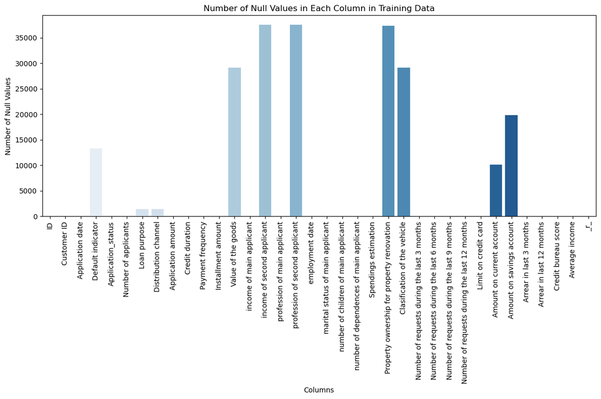

```python
# bar plot of missing values in each column
plt.figure(figsize=(12, 8))
snus.barplot(x=train_data.isnull().sum().index, y=train_data.isnull().sum().values, palette='Blues')
plt.xticks(rotation=90)
plt.xlabel('Columns')
plt.ylabel('Number of Null Values')
plt.title('Number of Null Values in Each Column in Training Data')
plt.tight_layout()
plt.show()
```

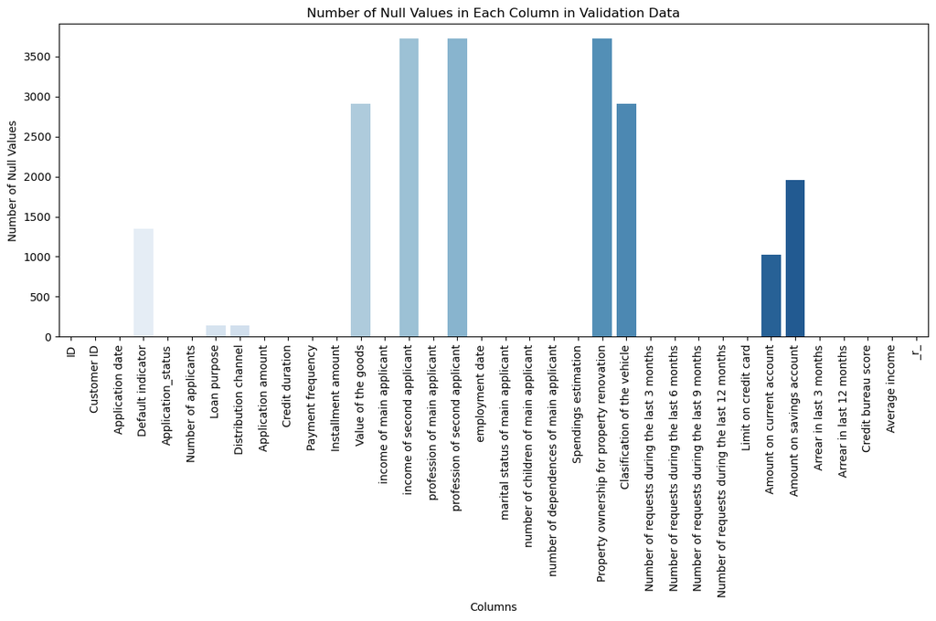

```python
# plot bar plot of missing values in each column
plt.figure(figsize=(12, 8))
snus.barplot(x=train_data.isnull().sum().index, y=val_data.isnull().sum().values, palette='Blues')
plt.xticks(rotation=90)
plt.xlabel('Columns')
plt.ylabel('Number of Null Values')
plt.title('Number of Null Values in Each Column in Validation Data')
plt.tight_layout()
plt.show()
```

Since there are numerous missing values in many columns, we decided to prepare a data cleaning function, data_cleaner(), to initially cleanse the data and change the datetime format to a more readable one. Additionally, the function creates a new column, 'work experience', by calculating the difference in days between the 'Application date' and 'employment date'. Some unnecessary columns such as 'ID', which do not influence probability of default, are also removed.

```python
train_data, val_data = data_cleaner(train_data), data_cleaner(val_data)
```

## Data Observations

After a thorough observation of the data, we decided to validate our assumptions regarding the significance of specific values in selected columns.

```python
# check hipothesis: if there is 1 applicant, the income of secound applicant is null
train_data[(train_data['income of second applicant'].isnull()) & (train_data['Number of applicants'].eq(1))].equals(train_data[train_data['income of second applicant'].isnull()])
```

```
True
```

```python
# check hipothesis: if there is 1 applicant, the profession of secound applicant is null
train_data[(train_data['profession of second applicant'].isnull()) & (train_data['Number of applicants'].eq(1))].equals(train_data[train_data['profession of second applicant'].isnull()])
```

```
True
```

```python
# check hipothesis: if Loan purpose is null, distribution channel is null
train_data[(train_data['Loan purpose'].isnull())].equals(train_data[train_data['Distribution channel'].isnull()])
```

```
True
```

```python
# check hipothesis: if Loan purpose is 1.0, Classification of the vechicle is not null
filtered_data = train_data[train_data['Loan purpose'] == 1.0]
result = filtered_data['Clasification of the vehicle'].notnull().all()
result
```

```
True
```

```python
# check hipothesis: if Loan purpose is 2.0, Property ownership for property renovation is not null
filtered_data = train_data[train_data['Loan purpose'] == 2.0]
result = filtered_data['Property ownership for property renovation'].notnull().all()
result
```

```
True
```

```python
# check amount of uneasy Distribution channel values (string: 'Direct' or string: 'Online') in training data
train_data[train_data['Distribution channel'].isin(['Direct', 'Online'])].shape[0]
```

```
277
```

```python
# check amount of uneasy Distribution channel values (string: 'Direct' or string: 'Online') in testing data
val_data[val_data['Distribution channel'].isin(['Direct', 'Online'])].shape[0]
```

```
0
```

Observing the data and confirming some of our hypotheses allowed us to create a new function, preprocess_data(), which aims to preprocess the data. Here's a brief description of this function:

- function drops certain columns
- performs one-hot encoding for 'Loan purpose' and other categorical columns
- creates new binary columns based on specific conditions
- drops unnecessary columns to prepare the data for modeling

```python
train_data, val_data = preprocess_data(train_data), preprocess_data(val_data)
```

[output not shown]

## Data Visualization

Lastly, we created valuable visualizations to aid in understanding relationships between data and other insights.

```python
train_data.shape
```

```
(35392, 50)
```

```python
val_data.shape
```

```
(3546, 50)
```

```python
# check if the coulmns are the same in both dataframes
train_data.columns.difference(val_data.columns)
```

```
Index([], dtype='object')
```

```python
# check if ther are still missing values in dataframe
train_data.isnull().sum()[train_data.isnull().sum() > 0]
```

```
Series([], dtype: int64)
```

```python
# check if ther are still missing values in dataframe
val_data.isnull().sum()[val_data.isnull().sum() > 0]
```

```
Series([], dtype: int64)
```

```python
# column in dataframe
train_data.columns
```

```
Index(['Application date', 'Default indicator', 'Number of applicants',
       'Application amount', 'Credit duration', 'Installment amount',
       'Value of the goods', 'income of main applicant',
       'income of second applicant', 'number of children of main applicant',
       'number of dependences of main applicant', 'Spendings estimation',
       'Number of requests during the last 3 months',
       'Number of requests during the last 6 months',
       'Number of requests during the last 9 months',
       'Number of requests during the last 12 months', 'Limit on credit card',
       'Amount on current account', 'Amount on savings account',
       'Arrear in last 3 months', 'Arrear in last 12 months',
       'Credit bureau score', 'Average income', '_r_', 'work experience',
       'loan_purpose_1_0', 'loan_purpose_1_1', 'loan_purpose_2_0',
       'loan_purpose_2_1', 'Distribution channel_2', 'Distribution channel_3',
       'Payment frequency_3', 'Payment frequency_6',
       'profession of main applicant_2', 'profession of main applicant_3',
       'profession of main applicant_4', 'profession of main applicant_5',
       'profession of main applicant_6', 'profession of main applicant_7',
       'profession of second applicant_1.0',
       'profession of second applicant_2.0',
       'profession of second applicant_3.0',
       'profession of second applicant_4.0',
       'profession of second applicant_5.0',
       'profession of second applicant_6.0',
       'profession of second applicant_7.0',
       'marital status of main applicant_1',
       'marital status of main applicant_2',
       'marital status of main applicant_3',
       'marital status of main applicant_4'],
      dtype='object')
```

We've successfully removed missing values, resulting in a change in the dimensions of our training data from (50,000, 36) to (35,392, 50), and of our testing data from (5,000, 36) to (3,546, 50).

### Correlation Heatmap

The correlation heatmap below reveals significant correlations between certain columns. For instance, 'Number of dependencies of main applicant' and 'Number of children of main applicant' exhibit a strong correlation. Similarly, Number of requests coumns in diffrent time intervals also appears strongly correlated to each other.

```python
corr_variables = ['Number of applicants', 'Application amount',
       'Credit duration', 'Installment amount', 'Value of the goods',
       'income of main applicant', 'income of second applicant',
       'number of children of main applicant',
       'number of dependences of main applicant', 'Spendings estimation',
       'Number of requests during the last 3 months',
       'Number of requests during the last 6 months',
       'Number of requests during the last 9 months',
       'Number of requests during the last 12 months', 'Limit on credit card',
       'Amount on current account', 'Amount on savings account',
       'Arrear in last 3 months', 'Arrear in last 12 months',
       'Credit bureau score', 'Average income', 'work experience']
```

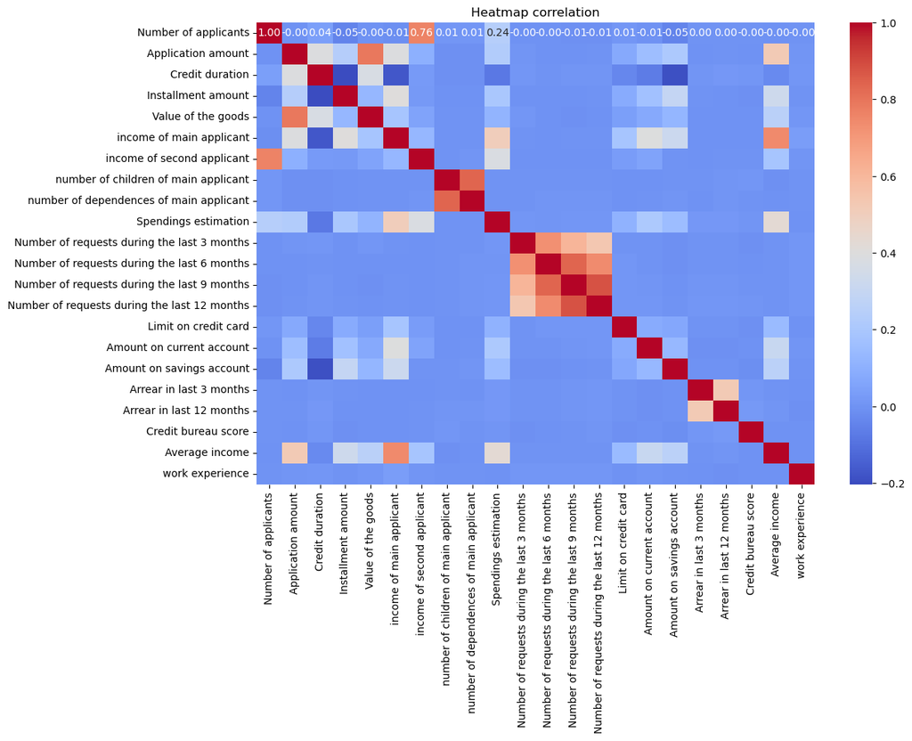

```python
corr_data = train_data[corr_variables].corr()

plt.figure(figsize=(12, 8))
snus.heatmap(corr_data, annot=True, cmap='coolwarm', fmt=".2f")
plt.title('Heatmap correlation')
plt.show()
```

### Pairplots

The pairplots illustrate relationships between pairs of variables in the dataset. However, it's challenging to interpret these plots due to their density and compression, making it difficult to discern details. Nevertheless, they occasionally reveal interesting patterns or relationships between variables.

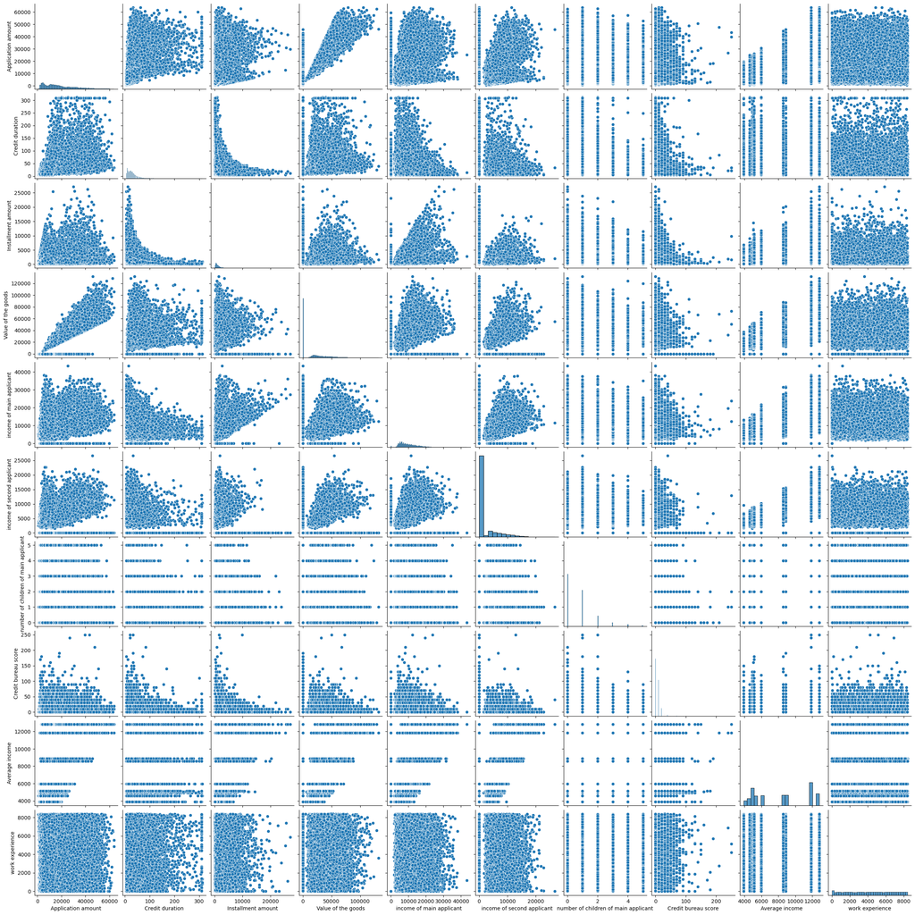

```python
pair_plot_variables = ['Application amount',
       'Credit duration', 'Installment amount', 'Value of the goods',
       'income of main applicant', 'income of second applicant',
       'number of children of main applicant',
       'Credit bureau score', 'Average income', 'work experience']

pair_data = train_data[pair_plot_variables]

snus.pairplot(pair_data)
plt.show()
```